# Lab 1: Randomized Trials

Week 1 HT 2022

### Lecutre & Data

[Data](https://dpir-ci.github.io/CI22/data/lupubrands.csv){: .btn .btn-blue } Lecture Slides{: .btn}

### Overview

Today we will be working with data from Noam Lupu’s work on [Party Brands and Partisanship](https://onlinelibrary.wiley.com/doi/abs/10.1111/j.1540-5907.2012.00615.x).

```r
brands=read.csv("https://github.com/dpir-ci/CI22/raw/gh-pages/docs/data/lupubrands.csv")

library(tidyverse)
library(magrittr)
library(tidymodels)

# tidy version:
brands_tidy <- as_tibble(brands)
```

Among these variables, let’s focus on the treatment variables and the outcome. There are four variables associated with the treatments and they are captured by the categorical variable`formulario`

- 1 = Control group
- 2 = Platform Information
- 3 = Alliance Switching
- 4 = Full Text

This variable is recoded into the dummies `frm2=1` which takes the value 1 if the respondent received the platform information treatment, `frm3=1` for alliance switching and `frm4=1` for the full text. Note the omitted dummy represents the control group.

For now, however, let’s use the original, categorical variable. As it is conventional, we aim to have the control group assigned to value 0.

```r
brands$treat=brands$formulario-1  #Assigning value 0 to the control group

# tidy version:
brands_tidy <- brands_tidy %>%
  mutate(treat = formulario - 1)
```

Did we define the treatment variable correctly? Let’s check again:

```r
head(cbind(brands$formulario, brands$treat, brands$frm2,brands$frm3,brands$frm4))
```

```
     [,1] [,2] [,3] [,4] [,5]
[1,]    3    2    0    1    0
[2,]    4    3    0    0    1
[3,]    1    0    0    0    0
[4,]    2    1    1    0    0
[5,]    3    2    0    1    0
[6,]    4    3    0    0    1
```

```r
assignment <- brands_tidy %>%
  select(formulario, treat, frm2, frm3, frm4)

head(assignment)
```

```
# A tibble: 6 x 5
  formulario treat  frm2  frm3  frm4
       <int> <dbl> <int> <int> <int>
1          3     2     0     1     0
2          4     3     0     0     1
3          1     0     0     0     0
4          2     1     1     0     0
5          3     2     0     1     0
6          4     3     0     0     1
```

Everything looks good! Taking the first row as example, when `formulario==3` (column1), the treatment variable we generated takes the value 2 (formulario-1) and the dummy for value 3 (frm3) take the value 1, whereas the others are 0.

### OLS Estimations

Lupu is interested in the effect of the three treatment conditions on partisanship. Among the two outcomes, `pid` (whether the individual identifies with a party) and `pidstr` (a 10 point scale representing the strength of the respondent’s party identification), we will focus below mainly on the latter.

**Exercise 1: Regress the strength of respondents’ party identity on the treatment**

**Reveal Answer**

```r
summary(lm(pidstr~treat, data=brands))
```

```
Call:
lm(formula = pidstr ~ treat, data = brands)

Residuals:
    Min      1Q  Median      3Q     Max
-7.3801 -1.3801  0.1589  1.7996  3.1589

Coefficients:
            Estimate Std. Error t value Pr(>|t|)
(Intercept)   7.3801     0.1828  40.363   <2e-16 ***
treat        -0.1797     0.1017  -1.766   0.0782 .
---
Signif. codes:  0 '***' 0.001 '**' 0.01 '*' 0.05 '.' 0.1 ' ' 1

Residual standard error: 2.283 on 395 degrees of freedom
  (802 observations deleted due to missingness)
Multiple R-squared:  0.007831,  Adjusted R-squared:  0.00532
F-statistic: 3.118 on 1 and 395 DF,  p-value: 0.07821
```

You can also run this regression using tidy:

```r
lin_fit <- linear_reg() %>%
  set_engine("lm") %>%
  fit(pidstr ~ treat, data = brands_tidy)

tidy(lin_fit)
```

```
# A tibble: 2 x 5
  term        estimate std.error statistic   p.value
  <chr>          <dbl>     <dbl>     <dbl>     <dbl>
1 (Intercept)    7.38      0.183     40.4  3.11e-142
2 treat         -0.180     0.102     -1.77 7.82e-  2
```

Does this regression make sense?

**Reveal Hint**

Run the command `class(brands$treat)`. What does it reveal about the variable?

**Reveal Answer**

It doesn’t! The OLS regression we just ran assumes that `treat` is a metric - or continuous - variable, such as vote shares or trade volume. Accordingly, the coefficient for `treat` shows the increase in the dependent variable associated with a one-unit increase in `treat` . Be aware of what the variable means, we know that this doesn’t make any sense. The outcomes of `treat` simply describe assignment to different treatments: The difference between them and order of the outcomes are arbitrary and do not actually mean anything. That is, `treat` is a *categorical variable*. We must thus run a factor regression model.

Let’s assign labels to each group first. This will help with the output and makes the coding easier.

```r
brands$treat[brands$treat==0]="Control"
brands$treat[brands$treat==1]="Platform"
brands$treat[brands$treat==2]="Switch"
brands$treat[brands$treat==3]="Full"

# tidy version:
brands_tidy <- brands_tidy %>%
  mutate(treat = recode(
    treat,
    `0` = "Control",
    `1` = "Platform",
    `2` = "Switch",
    `3` = "Full"
  ))
```

What will be our reference category here?

**Exercise 2: Regress the strength of respondents’ party identity on the treatment, telling R to model `treat` as factor variable. Interpret the coefficients.**

**Reveal Answer**

```r
summary(lm(pidstr~factor(treat), data=brands))
```

```
Call:
lm(formula = pidstr ~ factor(treat), data = brands)

Residuals:
    Min      1Q  Median      3Q     Max
-7.7934 -1.1389  0.2066  1.8611  3.8611

Coefficients:
                      Estimate Std. Error t value Pr(>|t|)
(Intercept)            7.13084    0.21532  33.118  < 2e-16 ***
factor(treat)Full     -0.09991    0.31225  -0.320  0.74916
factor(treat)Platform  0.66255    0.29556   2.242  0.02554 *
factor(treat)Switch   -0.99195    0.33950  -2.922  0.00368 **
---
Signif. codes:  0 '***' 0.001 '**' 0.01 '*' 0.05 '.' 0.1 ' ' 1

Residual standard error: 2.227 on 393 degrees of freedom
  (802 observations deleted due to missingness)
Multiple R-squared:  0.06022,   Adjusted R-squared:  0.05305
F-statistic: 8.395 on 3 and 393 DF,  p-value: 2.021e-05
```

```r
# tidy version:
lin_fit <- linear_reg() %>%
  set_engine("lm") %>%
  fit(pidstr ~ factor(treat), data = brands_tidy)

tidy(lin_fit)
```

```
# A tibble: 4 x 5
  term                  estimate std.error statistic   p.value
  <chr>                    <dbl>     <dbl>     <dbl>     <dbl>
1 (Intercept)             7.13       0.215    33.1   8.89e-116
2 factor(treat)Full      -0.0999     0.312    -0.320 7.49e-  1
3 factor(treat)Platform   0.663      0.296     2.24  2.55e-  2
4 factor(treat)Switch    -0.992      0.339    -2.92  3.68e-  3
```

As you can see, both models provide the exactly same results. Since R now understands that `treat` is a factor variable, the model treats each outcome as a separate variable and computes a different coefficient for each outcome. The coefficients exhibit the effect on the dependent variable associated with each respective type of treatment *compared to the reference category*. That is, receiving the switch treatment is associated with roughly a 1-point decrease in partisan attachment. Receiving the party platform treatment, on the other hand, is associated with a 0.66-point increase in party attachment. There is no significant effect, i.e. association, for respondents receiving the full treatment.

The OLS regression results look like mere mean differences. Let’s see if that is true. Why should it (not) be true?

```r
pid.control=mean(brands$pidstr[brands$treat=="Control"], na.rm=T)
pid.platform=mean(brands$pidstr[brands$treat=="Platform"],na.rm=T)
pid.switch=mean(brands$pidstr[brands$treat=="Switch"],na.rm=T)
pid.full=mean(brands$pidstr[brands$treat=="Full"],na.rm=T)

ate.platform=pid.platform-pid.control
ate.switch= pid.switch-pid.control
ate.full=pid.full-pid.control
```

```r
# tidy version:

pid.control <- brands_tidy %>% # E_Y_X_control
  filter(treat == "Control") %>%
  summarise(conditional_mean = mean(pidstr, na.rm = TRUE))

pid.platform <- brands_tidy %>% # E_Y_X_platform
  filter(treat == "Platform") %>%
  summarise(conditional_mean = mean(pidstr, na.rm = TRUE))

pid.switch <- brands_tidy %>% # E_Y_X_switch
  filter(treat == "Switch") %>%
  summarise(conditional_mean = mean(pidstr, na.rm = TRUE))

pid.switch <- brands_tidy %>% # E_Y_X_1_full
  filter(treat == "Full") %>%
  summarise(conditional_mean = mean(pidstr, na.rm = TRUE))

ate.platform=pid.platform-pid.control
ate.switch= pid.switch-pid.control
ate.full=pid.full-pid.control

ate.platform
```

```
  conditional_mean
1        0.6625473
```

```r
ate.switch
```

```
  conditional_mean
1      -0.09991329
```

```r
ate.full
```

```
  conditional_mean
1      -0.09991329
```

**Reveal Answer**

Firstly, we prefer models that can calculate measures of dispersion for the estimates. An OLS regression takes into account the distribution of variables as well as the number of observations. In other words, through substracting the means by treatment group we would not be able to know whether the ATEs are statistically significant. Secondly, the advantage of using OLS is that we can include (pre-treatment) covariates.

Still, can you think of other ways to estimate statistical uncertainty without using OLS?

### Randomization Checks

To ensure that respondents - or units - are randomly selected into treatment and control groups, we can do some randomization checks. We don’t only want to know whether covariates are associated with the outcome - we want to make sure there is no meaningful difference between respondents that received the different treatments. Here, again, comparing simple means would not be sufficient. What differences would be acceptable? Since we don’t want to rely on arbitrary cut-offs, we can use special tests. One of the, and maybe the most common one, is a `t-test`. It basically compares the means of two groups - taking into account standard errors and degrees of freedom - to test the null hypothesis of no difference between the means of the groups. Let’s check if the mean value of age is similar across treatment groups:

```r
t.test(brands$age~brands$frm2, data=brands, subset=c(brands$frm3!=1,brands$frm4!=1))
```

```
    Welch Two Sample t-test

data:  brands$age by brands$frm2
t = 0.82403, df = 615.13, p-value = 0.4102
alternative hypothesis: true difference in means is not equal to 0
95 percent confidence interval:
 -1.387264  3.393151
sample estimates:
mean in group 0 mean in group 1
       45.02007        44.01712
```

```r
#and, similarly, for the other treatments
t.test(brands$age~brands$frm3, data=brands, subset=c(brands$frm2!=1,brands$frm4!=1))
```

```
    Welch Two Sample t-test

data:  brands$age by brands$frm3
t = -0.29667, df = 594.69, p-value = 0.7668
alternative hypothesis: true difference in means is not equal to 0
95 percent confidence interval:
 -2.869676  2.116476
sample estimates:
mean in group 0 mean in group 1
       45.02007        45.39667
```

```r
t.test(brands$age~brands$frm4, data=brands, subset=c(brands$frm3!=1,brands$frm2!=1))
```

```
    Welch Two Sample t-test

data:  brands$age by brands$frm4
t = 0.007524, df = 539.28, p-value = 0.994
alternative hypothesis: true difference in means is not equal to 0
95 percent confidence interval:
 -2.520972  2.540358
sample estimates:
mean in group 0 mean in group 1
       44.69426        44.68456
```

With p-values nowhere near the conventional thresholds, we cannot reject the null hypothesis of no difference in any of these comparisons. Age is randomly distributed all treatment groups. Accordingly, we conclude that randomization in terms of age was successful.

**Exercise 6a: Check whether randomization was successful for `income`.**

**Reveal Answer**

```r
t.test(brands$income~brands$frm2, data=brands, subset=c(brands$frm3!=1,brands$frm4!=1))
```

```
    Welch Two Sample t-test

data:  brands$income by brands$frm2
t = -0.50244, df = 386.02, p-value = 0.6156
alternative hypothesis: true difference in means is not equal to 0
95 percent confidence interval:
 -0.4287813  0.2542368
sample estimates:
mean in group 0 mean in group 1
       4.948081        5.035354
```

```r
t.test(brands$income~brands$frm3, data=brands, subset=c(brands$frm2!=1,brands$frm4!=1))
```

```
    Welch Two Sample t-test

data:  brands$income by brands$frm3
t = -0.52723, df = 437.34, p-value = 0.5983
alternative hypothesis: true difference in means is not equal to 0
95 percent confidence interval:
 -0.4197579  0.2421877
sample estimates:
mean in group 0 mean in group 1
       4.948081        5.036866
```

```r
t.test(brands$income~brands$frm4, data=brands, subset=c(brands$frm3!=1,brands$frm2!=1))
```

```
    Welch Two Sample t-test

data:  brands$income by brands$frm4
t = -1.0524, df = 422.56, p-value = 0.2932
alternative hypothesis: true difference in means is not equal to 0
95 percent confidence interval:
 -0.5245158  0.1587156
sample estimates:
mean in group 0 mean in group 1
       4.911695        5.094595
```

**Exercise 6a: Check whether randomization was successful for `gender`.**

Note that the t-test uses Student’s t-distribution, which should generally be used for comparisons of continuous variables. Gender, however, is coded as a binary variable here. For binary variables, the `prop.test` command should be used, which is a comparison of proportions:

```r
table(brands$frm2,brands$female[brands$treat!=3 & brands$treat!=2])
```

```
      0   1
  0 366 538
  1 110 185
```

```r
prop.test(table(brands$frm2,brands$female[brands$treat!=3 & brands$treat!=2]))
```

```
    2-sample test for equality of proportions with continuity correction

data:  table(brands$frm2, brands$female[brands$treat != 3 & brands$treat != 2])
X-squared = 0.82165, df = 1, p-value = 0.3647
alternative hypothesis: two.sided
95 percent confidence interval:
 -0.03405038  0.09802218
sample estimates:
   prop 1    prop 2
0.4048673 0.3728814
```

Now, check the balance of `gender` between treatment and control group for the *switch* and *full* treatments.

**Reveal Answer**

```r
prop.test(table(brands$frm3,brands$female[brands$treat!=3 & brands$treat!=1]))
```

```
    2-sample test for equality of proportions with continuity correction

data:  table(brands$frm3, brands$female[brands$treat != 3 & brands$treat != 1])
X-squared = 0.80703, df = 1, p-value = 0.369
alternative hypothesis: two.sided
95 percent confidence interval:
 -0.09783690  0.03492668
sample estimates:
   prop 1    prop 2
0.3890747 0.4205298
```

```r
prop.test(table(brands$frm4,brands$female[brands$treat!=1 & brands$treat!=2]))
```

```
    2-sample test for equality of proportions with continuity correction

data:  table(brands$frm4, brands$female[brands$treat != 1 & brands$treat != 2])
X-squared = 0.90893, df = 1, p-value = 0.3404
alternative hypothesis: two.sided
95 percent confidence interval:
 -0.09976218  0.03319121
sample estimates:
   prop 1    prop 2
0.3886414 0.4219269
```

```r
# tidy version - need to double check:
library(broom)

brands_tidy %>%
  filter(treat ==  c("Switch", "Control")) %>%
  group_by(frm4, female) %>%
  summarise(cases = n()) %>%
  mutate(pop = sum(cases)) %>%
  rowwise() %>%
  mutate(tst = list(broom::tidy(prop.test(
    cases, pop, conf.level = 0.95
  )))) %>%
  tidyr::unnest(tst)
```

```
# A tibble: 2 x 12
# Groups:   frm4 [1]
   frm4 female cases   pop estimate statistic  p.value parameter conf.low
  <int>  <int> <int> <int>    <dbl>     <dbl>    <dbl>     <int>    <dbl>
1     0      0   118   299    0.395      12.9 0.000336         1    0.339
2     0      1   181   299    0.605      12.9 0.000336         1    0.547
# ... with 3 more variables: conf.high <dbl>, method <chr>, alternative <chr>
```

An equivalent to a ttest is the kolomogorov smirnov test that compares distributions (only works for continuous variables)

$$D = \max_{1 \leq i \leq N} (F(Y_i) - \frac{i - 1}{N}, \frac{i}{N} - F(Y_i))$$

```r
#age
ks.test(brands$age[brands$frm3!=1 & brands$frm2!=1 & brands$frm4==1],
        brands$age[brands$frm3!=1 & brands$frm2!=1 & brands$frm4==0]) # Fullinfo vs Control
```

```
    Two-sample Kolmogorov-Smirnov test

data:  brands$age[brands$frm3 != 1 & brands$frm2 != 1 & brands$frm4 == 1] and brands$age[brands$frm3 != 1 & brands$frm2 != 1 & brands$frm4 == 0]
D = 0.068076, p-value = 0.4925
alternative hypothesis: two-sided
```

```r
ks.test(brands$age[brands$frm3==1 & brands$frm2!=1 & brands$frm4!=1],
        brands$age[brands$frm3==0 & brands$frm2!=1 & brands$frm4!=1]) # Switching vs Control
```

```
    Two-sample Kolmogorov-Smirnov test

data:  brands$age[brands$frm3 == 1 & brands$frm2 != 1 & brands$frm4 != 1] and brands$age[brands$frm3 == 0 & brands$frm2 != 1 & brands$frm4 != 1]
D = 0.05, p-value = 0.8475
alternative hypothesis: two-sided
```

```r
ks.test(brands$age[brands$frm3!=1 & brands$frm2==1 & brands$frm4!=1],
        brands$age[brands$frm3!=1 & brands$frm2==0 & brands$frm4!=1]) # Platform vs control
```

```
    Two-sample Kolmogorov-Smirnov test

data:  brands$age[brands$frm3 != 1 & brands$frm2 == 1 & brands$frm4 != 1] and brands$age[brands$frm3 != 1 & brands$frm2 == 0 & brands$frm4 != 1]
D = 0.055982, p-value = 0.7426
alternative hypothesis: two-sided
```

```r
#income
ks.test(brands$income[brands$frm3!=1 & brands$frm2!=1 & brands$frm4==1],
        brands$income[brands$frm3!=1 & brands$frm2!=1 & brands$frm4==0]) # Fullinfo vs Control
```

```
    Two-sample Kolmogorov-Smirnov test

data:  brands$income[brands$frm3 != 1 & brands$frm2 != 1 & brands$frm4 == 1] and brands$income[brands$frm3 != 1 & brands$frm2 != 1 & brands$frm4 == 0]
D = 0.080408, p-value = 0.4711
alternative hypothesis: two-sided
```

```r
ks.test(brands$income[brands$frm3==1 & brands$frm2!=1 & brands$frm4!=1],
        brands$income[brands$frm3==0 & brands$frm2!=1 & brands$frm4!=1]) # Switching vs Control
```

```
    Two-sample Kolmogorov-Smirnov test

data:  brands$income[brands$frm3 == 1 & brands$frm2 != 1 & brands$frm4 != 1] and brands$income[brands$frm3 == 0 & brands$frm2 != 1 & brands$frm4 != 1]
D = 0.06266, p-value = 0.7832
alternative hypothesis: two-sided
```

```r
ks.test(brands$income[brands$frm3!=1 & brands$frm2==1 & brands$frm4!=1],
        brands$income[brands$frm3!=1 & brands$frm2==0 & brands$frm4!=1]) # Platform vs control
```

```
    Two-sample Kolmogorov-Smirnov test

data:  brands$income[brands$frm3 != 1 & brands$frm2 == 1 & brands$frm4 != 1] and brands$income[brands$frm3 != 1 & brands$frm2 == 0 & brands$frm4 != 1]
D = 0.081174, p-value = 0.4969
alternative hypothesis: two-sided
```

There are alternatives of running these randomization tests. For example, we could redefine all categorical variables into dummies and run `prop.test()` for all. A more conservative way of testing this for categorical variables is to run a chi-square test, for example:

```r
table(brands[c(brands$frm3!=1,brands$frm4!=1),]$income,brands[c(brands$frm3!=1,brands$frm4!=1),]$frm2)
```

```
       0   1
  1    5   2
  2   30  10
  3   78  36
  4   86  30
  5  113  60
  6   47  28
  7   32   4
  8   17  12
  9    8   5
  10  27  11
```

```r
chisq.test(table(brands[c(brands$frm3!=1,brands$frm4!=1),]$income,brands[c(brands$frm3!=1,brands$frm4!=1),]$frm2))
```

```
    Pearson's Chi-squared test

data:  table(brands[c(brands$frm3 != 1, brands$frm4 != 1), ]$income,     brands[c(brands$frm3 != 1, brands$frm4 != 1), ]$frm2)
X-squared = 13.199, df = 9, p-value = 0.1538
```

Finally, one could also do a multivariate randomization check. This is is easier if the treatment is binary. In our case, we need to use some packages.

```r
#install.packages("nnet")
require(nnet)
```

and run

```r
multi=multinom(treat~age+income+educgrp+info+female, data=brands)
summary(multi)
```

```
Call:
multinom(formula = treat ~ age + income + educgrp + info + female,
    data = brands)

Coefficients:
         (Intercept)          age     income     educgrp        info
Full       0.1602862 -0.001568734 0.09956541 -0.09463015 -0.15089367
Platform  -0.1210902 -0.006817290 0.04245140  0.10252286 -0.13096349
Switch    -0.1435468 -0.002097874 0.02905994  0.10144407 -0.01909619
              female
Full     -0.35475460
Platform -0.08517474
Switch   -0.28808492

Std. Errors:
         (Intercept)         age     income   educgrp      info    female
Full       0.4940061 0.005796394 0.05472623 0.1382340 0.1508345 0.2004447
Platform   0.5092535 0.006053721 0.05649825 0.1411189 0.1552429 0.2091415
Switch     0.4956036 0.005825677 0.05532334 0.1374163 0.1507181 0.2014886

Residual Deviance: 2339.921
AIC: 2375.921
```

Now, let’s find out the p-values.

```r
alpha=summary(multi)$coefficients/summary(multi)$standard.errors
abs(alpha)
```

```
         (Intercept)       age    income   educgrp      info   female
Full       0.3244620 0.2706395 1.8193362 0.6845651 1.0003925 1.769838
Platform   0.2377798 1.1261321 0.7513755 0.7264997 0.8436036 0.407259
Switch     0.2896404 0.3601082 0.5252745 0.7382246 0.1267014 1.429783
```

```r
p <- (1 - pnorm(abs(alpha), 0, 1)) * 2
p
```

```
         (Intercept)       age     income   educgrp      info     female
Full       0.7455883 0.7866683 0.06886015 0.4936184 0.3171206 0.07675412
Platform   0.8120519 0.2601096 0.45242668 0.4675325 0.3988909 0.68381778
Switch     0.7720913 0.7187662 0.59939242 0.4603780 0.8991768 0.15277942
```

Only income and gender in the *Full* treatment are suspect for imbalance. All other covariates are fine!

What if the treatment is binary? Suppose we were only interested in the Platform Vs Control treatment effect. How should you check if randomization worked?

One options is to use OLS:

```r
require(coefplot) #loading package to make the plot
```

```r
PlatVControl=brands[c(brands$treat=="Control" | brands$treat=="Platform"),]
randcheck=lm(frm2~age+income+educgrp+info+female,data=PlatVControl)
summary(randcheck)
```

```
Call:
lm(formula = frm2 ~ age + income + educgrp + info + female, data = PlatVControl)

Residuals:
    Min      1Q  Median      3Q     Max
-0.5850 -0.4698 -0.3815  0.5116  0.6805

Coefficients:
             Estimate Std. Error t value Pr(>|t|)
(Intercept)  0.493851   0.136435   3.620 0.000332 ***
age         -0.001956   0.001640  -1.193 0.233674
income       0.011737   0.013914   0.844 0.399391
educgrp      0.020109   0.034659   0.580 0.562103
info        -0.033649   0.039130  -0.860 0.390330
female      -0.026027   0.051965  -0.501 0.616740
---
Signif. codes:  0 '***' 0.001 '**' 0.01 '*' 0.05 '.' 0.1 ' ' 1

Residual standard error: 0.4996 on 410 degrees of freedom
  (180 observations deleted due to missingness)
Multiple R-squared:  0.01198,   Adjusted R-squared:  -6.44e-05
F-statistic: 0.9947 on 5 and 410 DF,  p-value: 0.4206
```

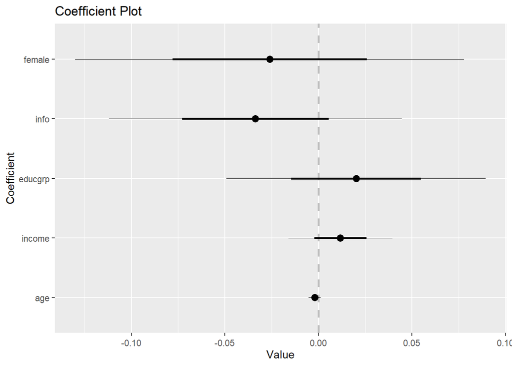

```r
coefplot(randcheck, intercept=F, col="black" )
```

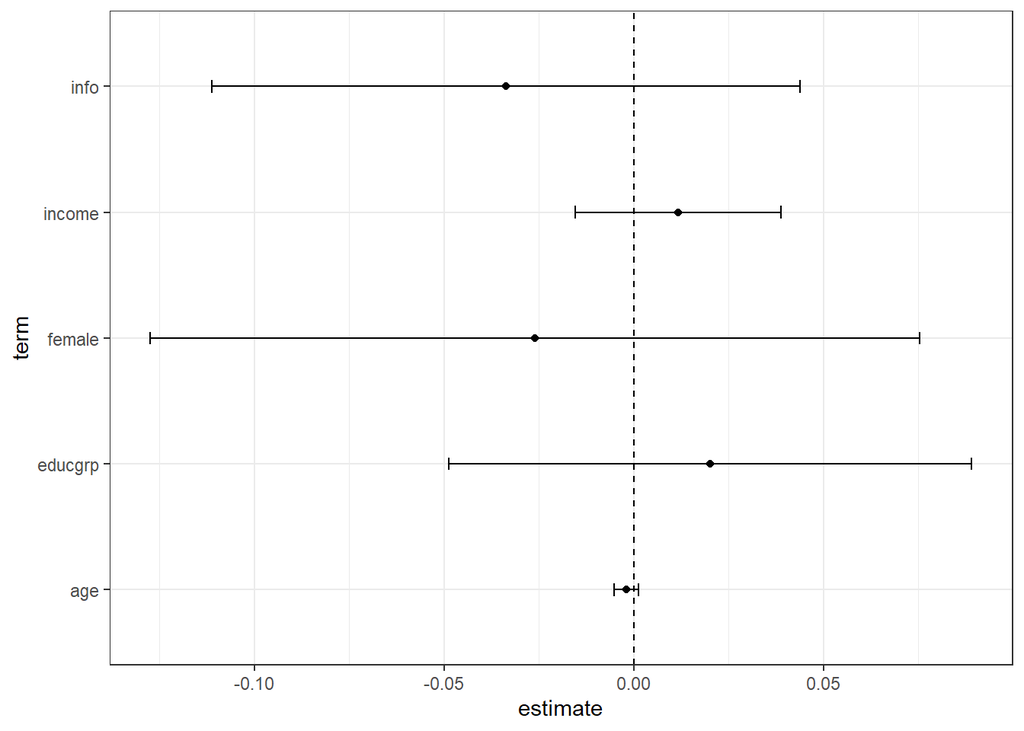

```r
# tidy version:
library(estimatr)

PlatVControl_tidy <- brands_tidy %>%
  filter(treat %in% c("Control", "Platform"))

randcheck_tidy <- lm_robust(frm2~age+income+educgrp+info+female,data=PlatVControl_tidy) # but using HC2 standard errors (heteroscedasticity-consistent standard errors)

randcheck_tidy %>%
  tidy %>%
  filter(term != "(Intercept)") %>%
  ggplot(aes(y = term, x = estimate)) +
  geom_vline(xintercept = 0, linetype = 2) +
  geom_point() +
  geom_errorbarh(aes(
    xmin = conf.low,
    xmax = conf.high,
    height = 0.1
  )) +
  theme_bw()
```

Option 2 (logit):

```r
randchecklogit=glm(frm2~age+income+educgrp+info+female,data=PlatVControl, family=binomial(logit) )
summary(randchecklogit) # (the deviance residual is -2*log likelihood)
```

```
Call:
glm(formula = frm2 ~ age + income + educgrp + info + female,
    family = binomial(logit), data = PlatVControl)

Deviance Residuals:
    Min       1Q   Median       3Q      Max
-1.3271  -1.1259  -0.9809   1.1975   1.5007

Coefficients:
             Estimate Std. Error z value Pr(>|z|)
(Intercept) -0.023398   0.549889  -0.043    0.966
age         -0.007969   0.006651  -1.198    0.231
income       0.047572   0.056095   0.848    0.396
educgrp      0.081712   0.139860   0.584    0.559
info        -0.136592   0.158441  -0.862    0.389
female      -0.105979   0.209682  -0.505    0.613

(Dispersion parameter for binomial family taken to be 1)

    Null deviance: 575.07  on 415  degrees of freedom
Residual deviance: 570.05  on 410  degrees of freedom
  (180 observations deleted due to missingness)
AIC: 582.05

Number of Fisher Scoring iterations: 4
```

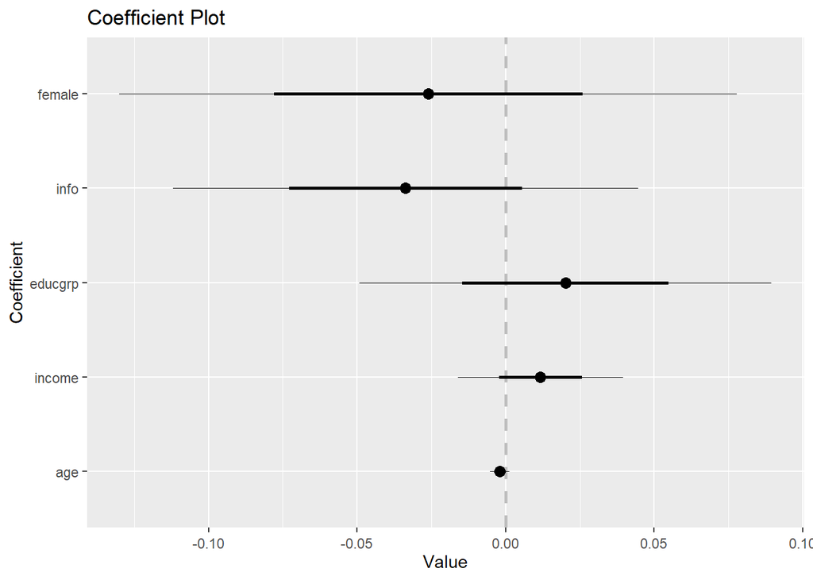

```r
coefplot(randcheck, intercept=F, col="black" )
```

```r
# p- value
with(randchecklogit, pchisq(null.deviance - deviance, df.null - df.residual, lower.tail = FALSE))
```

```
[1] 0.4137171
```

```r
logLik(randchecklogit)
```

```
'log Lik.' -285.0273 (df=6)
```

```r
# tidyverse version
library(tidymodels)
library(parsnip)

# convert the treatment variable into a factor:
PlatVControl_tidy <- PlatVControl_tidy %>%
  mutate(frm2 = factor(x = frm2,
                           levels = 0:1,
                           labels = c("Control", "Treatment")))


log_mod <- logistic_reg() %>%
  set_engine("glm")

mult_fit  <- log_mod %>%
  fit(frm2 ~ age + income + educgrp + info + female, data = PlatVControl_tidy)
mult_fit
```

```
parsnip model object

Fit time:  20ms

Call:  stats::glm(formula = frm2 ~ age + income + educgrp + info + female,
    family = stats::binomial, data = data)

Coefficients:
(Intercept)          age       income      educgrp         info       female
  -0.023398    -0.007969     0.047572     0.081712    -0.136592    -0.105979

Degrees of Freedom: 415 Total (i.e. Null);  410 Residual
  (180 observations deleted due to missingness)
Null Deviance:      575.1
Residual Deviance: 570.1    AIC: 582.1
```

```r
tidy(mult_fit)
```

```
# A tibble: 6 x 5
  term        estimate std.error statistic p.value
  <chr>          <dbl>     <dbl>     <dbl>   <dbl>
1 (Intercept) -0.0234    0.550     -0.0426   0.966
2 age         -0.00797   0.00665   -1.20     0.231
3 income       0.0476    0.0561     0.848    0.396
4 educgrp      0.0817    0.140      0.584    0.559
5 info        -0.137     0.158     -0.862    0.389
6 female      -0.106     0.210     -0.505    0.613
```

So, with binary treatment variables, one should use OLS or logit.